# This is Assignment 12 - Michael Navarro

```python
# Assignment Imports
import numpy as np
import pandas as pd
import seaborn as sns

class display(object):
    """Display HTML representation of multiple objects"""
    template = """<div style="float: left; padding: 10px;">
    <p style='font-family:"Courier New", Courier, monospace'>{0}</p>{1}
    </div>"""
    def __init__(self, *args):
        self.args = args

    def _repr_html_(self):
        return '\n'.join(self.template.format(a, eval(a)._repr_html_())
                         for a in self.args)

    def __repr__(self):
        return '\n\n'.join(a + '\n' + repr(eval(a))
                           for a in self.args)
```

## Requirement 03

```python
# Determine the number of rows and coulmns in the Planets dataset from Seaborn

planets = sns.load_dataset('planets')
print(f'Number of rows (planets): {planets.shape[0]}')
print(f'Number of coloumns (attributes): {planets.shape[1]}')
```

```
Number of rows (planets): 1035
Number of coloumns (attributes): 6
```

## Requirement 04

```python
# Show top 50 rows using the head() method

print(f'Displaying the top 50 rows:\n{planets.head(50)}')
```

```
Displaying the top 50 rows:
                       method  number  orbital_period     mass  distance  year
0             Radial Velocity       1      269.300000   7.1000     77.40  2006
1             Radial Velocity       1      874.774000   2.2100     56.95  2008
2             Radial Velocity       1      763.000000   2.6000     19.84  2011
3             Radial Velocity       1      326.030000  19.4000    110.62  2007
4             Radial Velocity       1      516.220000  10.5000    119.47  2009
5             Radial Velocity       1      185.840000   4.8000     76.39  2008
6             Radial Velocity       1     1773.400000   4.6400     18.15  2002
7             Radial Velocity       1      798.500000      NaN     21.41  1996
8             Radial Velocity       1      993.300000  10.3000     73.10  2008
9             Radial Velocity       2      452.800000   1.9900     74.79  2010
10            Radial Velocity       2      883.000000   0.8600     74.79  2010
11            Radial Velocity       1      335.100000   9.8800     39.43  2009
12            Radial Velocity       1      479.100000   3.8800     97.28  2008
```

[output cut: 37 more lines]

## Requirement 05

```python
# Use the following seeds for RandomState() to demonstrate that the function
# returns the same random numbers for constant seeds:
#   • RandomState(42)
#   • RandomState(99)
#   • RandomState(42)
#   • RandomState(99)

rng = np.random.RandomState(42)
ser = pd.Series(rng.rand(5))
print(f'Numbers using seed of 42:\n{ser}\n')

rng = np.random.RandomState(99)
ser = pd.Series(rng.rand(5))
print(f'Numbers using seed of 99:\n{ser}\n')

rng = np.random.RandomState(42)
ser = pd.Series(rng.rand(5))
print(f'Numbers using seed of 42:\n{ser}\n')

rng = np.random.RandomState(99)
ser = pd.Series(rng.rand(5))
print(f'Numbers using seed of 99:\n{ser}\n')
```

```
Numbers using seed of 42:
0    0.374540
1    0.950714
2    0.731994
3    0.598658
4    0.156019
dtype: float64

Numbers using seed of 99:
0    0.672279
1    0.488078
2    0.825495
3    0.031446
4    0.808050
dtype: float64

Numbers using seed of 42:
0    0.374540
1    0.950714
2    0.731994
3    0.598658
4    0.156019
dtype: float64

Numbers using seed of 99:
0    0.672279
1    0.488078
2    0.825495
3    0.031446
4    0.808050
dtype: float64
```

## Requirement 06

```python
# Use rand(5) to produce a similar dataframe to the example

df = pd.DataFrame({'Texas': rng.rand(5),
                   'Georgia': rng.rand(5),
                   'Maine': rng.rand(5)})
df
```

|  | Texas | Georgia | Maine |
| --- | --- | --- | --- |
| 0 | 0.565617 | 0.769793 | 0.395454 |
| 1 | 0.297622 | 0.746767 | 0.973956 |
| 2 | 0.046696 | 0.377439 | 0.524415 |
| 3 | 0.990627 | 0.494147 | 0.093613 |
| 4 | 0.006826 | 0.928948 | 0.813308 |

## Requirement 07

```python
# Output the common aggregates for the Planets dataset dropping rows with missing values.

planets.dropna().describe()
```

|  | number | orbital_period | mass | distance | year |
| --- | --- | --- | --- | --- | --- |
| count | 498.00000 | 498.000000 | 498.000000 | 498.000000 | 498.000000 |
| mean | 1.73494 | 835.778671 | 2.509320 | 52.068213 | 2007.377510 |
| std | 1.17572 | 1469.128259 | 3.636274 | 46.596041 | 4.167284 |
| min | 1.00000 | 1.328300 | 0.003600 | 1.350000 | 1989.000000 |
| 25% | 1.00000 | 38.272250 | 0.212500 | 24.497500 | 2005.000000 |
| 50% | 1.00000 | 357.000000 | 1.245000 | 39.940000 | 2009.000000 |
| 75% | 2.00000 | 999.600000 | 2.867500 | 59.332500 | 2011.000000 |
| max | 6.00000 | 17337.500000 | 25.000000 | 354.000000 | 2014.000000 |

## Requirement 08

```python
# Output a list of the datasets that install with Seaborn
count = 1

print(f'Datasets in Seaborn')
for dataset in sns.get_dataset_names():
    print(f'{count}. {dataset.title()}')
    count += 1
# end if
```

```
Datasets in Seaborn
1. Anagrams
2. Anscombe
3. Attention
4. Brain_Networks
5. Car_Crashes
6. Diamonds
7. Dots
8. Exercise
9. Flights
10. Fmri
11. Gammas
12. Geyser
13. Iris
14. Mpg
15. Penguins
16. Planets
17. Taxis
18. Tips
19. Titanic
```

## Requirement 09

```python
# Output the top five rows of five Pandas datasets

print(f'Anagrams Dataset:\n{sns.load_dataset("anagrams").head()}')
print(f'Diamonds Dataset:\n{sns.load_dataset("diamonds").head()}')
print(f'Flights Dataset:\n{sns.load_dataset("flights").head()}')
print(f'Geyser Dataset:\n{sns.load_dataset("geyser").head()}')
print(f'Tips Dataset:\n{sns.load_dataset("tips").head()}')
```

```
Anagrams Dataset:
   subidr    attnr  num1  num2  num3
0       1  divided     2   4.0     7
1       2  divided     3   4.0     5
2       3  divided     3   5.0     6
3       4  divided     5   7.0     5
4       5  divided     4   5.0     8
Diamonds Dataset:
   carat      cut color clarity  depth  table  price     x     y     z
0   0.23    Ideal     E     SI2   61.5   55.0    326  3.95  3.98  2.43
1   0.21  Premium     E     SI1   59.8   61.0    326  3.89  3.84  2.31
2   0.23     Good     E     VS1   56.9   65.0    327  4.05  4.07  2.31
3   0.29  Premium     I     VS2   62.4   58.0    334  4.20  4.23  2.63
4   0.31     Good     J     SI2   63.3   58.0    335  4.34  4.35  2.75
Flights Dataset:
```

[output cut: 20 more lines]

## Requirement 10

```python
# Apply the describe() method to a planets.groupby() object

planets.groupby('method')['distance'].describe()
```

| method | count | mean | std | min | 25% | 50% | 75% | max |
| --- | --- | --- | --- | --- | --- | --- | --- | --- |
| Astrometry | 2.0 | 17.875000 | 4.094148 | 14.98 | 16.4275 | 17.875 | 19.3225 | 20.77 |
| Eclipse Timing Variations | 4.0 | 315.360000 | 213.203907 | 130.72 | 130.7200 | 315.360 | 500.0000 | 500.00 |
| Imaging | 32.0 | 67.715937 | 53.736817 | 7.69 | 22.1450 | 40.395 | 132.6975 | 165.00 |
| Microlensing | 10.0 | 4144.000000 | 2076.611556 | 1760.00 | 2627.5000 | 3840.000 | 4747.5000 | 7720.00 |
| Orbital Brightness Modulation | 2.0 | 1180.000000 | 0.000000 | 1180.00 | 1180.0000 | 1180.000 | 1180.0000 | 1180.00 |
| Pulsar Timing | 1.0 | 1200.000000 | NaN | 1200.00 | 1200.0000 | 1200.000 | 1200.0000 | 1200.00 |
| Pulsation Timing Variations | 0.0 | NaN | NaN | NaN | NaN | NaN | NaN | NaN |
| Radial Velocity | 530.0 | 51.600208 | 45.559381 | 1.35 | 24.4125 | 40.445 | 59.2175 | 354.00 |
| Transit | 224.0 | 599.298080 | 913.876990 | 38.00 | 200.0000 | 341.000 | 650.0000 | 8500.00 |
| Transit Timing Variations | 3.0 | 1104.333333 | 915.819487 | 339.00 | 597.0000 | 855.000 | 1487.0000 | 2119.00 |

## Requirement 11

```python
# Apply the describe() and unstack() methods to a planets.groupby() object

print('My output would not turn out the same even if I directly copied all the commands from the book.')
planets.groupby('method')['distance'].describe().unstack()
```

```
My output would not turn out the same even if I directly copied all the commands from the book.
```

```
       method
count  Astrometry                          2.0
       Eclipse Timing Variations           4.0
       Imaging                            32.0
       Microlensing                       10.0
       Orbital Brightness Modulation       2.0
                                         ...
max    Pulsar Timing                    1200.0
       Pulsation Timing Variations         NaN
       Radial Velocity                   354.0
       Transit                          8500.0
       Transit Timing Variations        2119.0
Length: 80, dtype: float64
```

## Requirement 12

```python
# Output the first ten rows from the Seaborn titanic dataset

titanic = sns.load_dataset('titanic')
print(f'Displaying the top 5 rows:\n{titanic.head()}')
```

```
Displaying the top 5 rows:
   survived  pclass     sex   age  sibsp  parch     fare embarked  class  \
0         0       3    male  22.0      1      0   7.2500        S  Third
1         1       1  female  38.0      1      0  71.2833        C  First
2         1       3  female  26.0      0      0   7.9250        S  Third
3         1       1  female  35.0      1      0  53.1000        S  First
4         0       3    male  35.0      0      0   8.0500        S  Third

     who  adult_male deck  embark_town alive  alone
0    man        True  NaN  Southampton    no  False
1  woman       False    C    Cherbourg   yes  False
2  woman       False  NaN  Southampton   yes   True
3  woman       False    C  Southampton   yes  False
4    man        True  NaN  Southampton    no   True
```

## Requirement 13

```python
# Use the groupby() method with the titanic dataset to show mean survival rates by sex and class

print(f'Mean Survival Rates By Sex and Class:')
titanic.groupby(['sex', 'class'])['survived'].aggregate('mean').unstack()
```

```
Mean Survival Rates By Sex and Class:
```

| class sex | First | Second | Third |
| --- | --- | --- | --- |
| female | 0.968085 | 0.921053 | 0.500000 |
| male | 0.368852 | 0.157407 | 0.135447 |

## Requirement 14

```python
# Use the pivot_table() method with the titanic dataset to show mean survival rates by sex and class

titanic.pivot_table('survived', index='sex', columns='class')
```

| class sex | First | Second | Third |
| --- | --- | --- | --- |
| female | 0.968085 | 0.921053 | 0.500000 |
| male | 0.368852 | 0.157407 | 0.135447 |

## Requirement 15

```python
# Use a multi-level pivot table to include age with the previous requirement

age = pd.cut(titanic['age'], [0, 21, 85])
titanic.pivot_table('survived', ['sex', age], 'class')
```

| sex | class age | First | Second | Third |
| --- | --- | --- | --- | --- |
| female | (0, 21] | 0.937500 | 1.000000 | 0.490196 |
|  | (21, 85] | 0.971014 | 0.894737 | 0.431373 |
| male | (0, 21] | 0.500000 | 0.454545 | 0.177778 |
|  | (21, 85] | 0.387097 | 0.064935 | 0.134969 |

## Requirement 16

```python
# Use the pivot_table() method to show row data by sex and column data by
# class when using aggfunc argument to aggregate survived by using sum and fare by mean

titanic.pivot_table(index='sex', columns='class',
                    aggfunc={'survived':sum, 'fare':'mean'})
```

| class sex | fare First | fare Second | fare Third | survived First | survived Second | survived Third |
| --- | --- | --- | --- | --- | --- | --- |
| female | 106.125798 | 21.970121 | 16.118810 | 91 | 70 | 72 |
| male | 67.226127 | 19.741782 | 12.661633 | 45 | 17 | 47 |

## Requirement 17

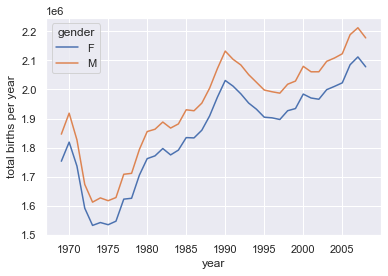

```python
# Use matplotlib, pivot_table(), and the Seaborn births dataset to produce a plot of total births per year
%matplotlib inline
import matplotlib.pyplot as plt

sns.set()  # use Seaborn styles

births = pd.read_csv('births.csv')
births.pivot_table('births', index='year', columns='gender', aggfunc='sum').plot()
plt.ylabel('total births per year');
```

## Requirement 18

```python
# Create an np array x based on range(11). Output the cubed contents of x.

x = np.array(range(11))
print(f'Contents of X cubed:{x ** 3}')
```

```
Contents of X cubed:[   0    1    8   27   64  125  216  343  512  729 1000]
```

## Requirement 19

```python
# Use list comprehension with a list of string to convert all entries to
# uppercase. What happens when the list contains the value of None?

data = ['john', 'jacoB', 'Josh', 'JaCk']
print(f'Original Contents: {data}')
print(f'Contents Uppercased: {[s.upper() for s in data]}')
```

```
Original Contents: ['john', 'jacoB', 'Josh', 'JaCk']
Contents Uppercased: ['JOHN', 'JACOB', 'JOSH', 'JACK']
```

If there is a value of "None", the function call will error out.

## Requirement 20

```python
# Convert the list from the previous requirement into a Pandas series.
# Demonstrate conversion to uppercase with the Pandas series

names = pd.Series(data)
names.str.upper()
```

```
0     JOHN
1    JACOB
2     JOSH
3     JACK
dtype: object
```

## Requirement 21

```python
# Demonstrate the use of five Pandas str methods on a Pandas series named
# states created from a list of seven names of U.S. states

state_list = ['texas', 'CalifoRnia', 'IoWa', 'neVada', 'oregoN']
states = pd.Series(state_list)

print(f'Original Contents: {state_list}\n')
print(f'Lower Cased Contents:\n{states.str.lower()}')
print(f'Titled Contents:\n{states.str.title()}')
print(f'Capitalized Contents:\n{states.str.capitalize()}')
print(f'Swapped Cased Contents:\n{states.str.swapcase()}')
```

```
Original Contents: ['texas', 'CalifoRnia', 'IoWa', 'neVada', 'oregoN']

Lower Cased Contents:
0         texas
1    california
2          iowa
3        nevada
4        oregon
dtype: object
Titled Contents:
0         Texas
1    California
2          Iowa
3        Nevada
4        Oregon
dtype: object
Capitalized Contents:
0         Texas
1    California
2          Iowa
3        Nevada
4        Oregon
dtype: object
Swapped Cased Contents:
0         TEXAS
1    cALIFOrNIA
2          iOwA
3        NEvADA
4        OREGOn
dtype: object
```

## Requirement 22

```python
# Demonstrate the use of three regular expression examples using the states Pandas series.

print(f'Number of "i" in each state name:')
print(f"{states.str.count(r'([Ii])')}")

print(f'State names that begin and end with a vowel:')
print(f"{states.str.contains(r'^[AEIOU].*[aeiou]$')}")

print(f'State names split on "o" or "u":')
print(f"{states.str.split('([OUou])')}")
```

```
Number of "i" in each state name:
0    0
1    2
2    1
3    0
4    0
dtype: int64
State names that begin and end with a vowel:
0    False
1    False
2     True
3    False
4    False
dtype: bool
State names split on "o" or "u":
0             [texas]
1    [Calif, o, Rnia]
2          [I, o, Wa]
3            [neVada]
4    [, o, reg, o, N]
dtype: object
```

## Requirement 23

```python
# Demonstrate the use of three miscellaneous methods using the states Pandas series

print(f'First letter of every state name:')
print(f"{states.str.get(0).str.upper()}")

print(f'State names concatenated:')
print(f"{states.str.title().str.cat()}")

print(f'State names repeated:')
print(f"{states.str.title().str.repeat(2)}")
```

```
First letter of every state name:
0    T
1    C
2    I
3    N
4    O
dtype: object
State names concatenated:
TexasCaliforniaIowaNevadaOregon
State names repeated:
0              TexasTexas
1    CaliforniaCalifornia
2                IowaIowa
3            NevadaNevada
4            OregonOregon
dtype: object
```

## Requirement 24

IN [18-20]: The JSON information is read and formatted into a Pandas data object named recipes.

IN [21-23]: We get a count of all the rows and columns in the data object and look at the first entry. Lastly, we get get statistical data on the length of the ingrediants attribute for all row items (recipes).

IN [24-27]: We start by looking at the recipe with the longest ingredient attribute. This is followed by a check to see which recipes are breakfast items. Lastly, we check which recipes contain cinnamon and which misspell the word cinnamon as cinamon.

IN [28-31]: We create a list of spices. Using this list, to create a new boolean dataframe for each recipe to see if the recipe contains each of the spices in the list and display the first 5 recipes. Afterwards, we create a query to see which recipes contain either parsely, paprika or tarragon. Using the result of the query, we create print out the results using thier index in the data blob as the first attribute and the name of the recipe as the second attribute.

## Requirement 25

```python
# Create a NumPy date array using the date 01Jan2020 (use the date format
# of your choice). Use the arange() method to create an array of seven dates
# starting with 01Jan2020 (use the date format of your choice)

date = np.array('2020-01-01 12:00', dtype=np.datetime64)
print(f'Numpy array: {date}')
print(f'Arange of seven: {date + np.arange(7)}')
```

```
Numpy array: 2020-01-01T12:00
Arange of seven: ['2020-01-01T12:00' '2020-01-01T12:01' '2020-01-01T12:02'
 '2020-01-01T12:03' '2020-01-01T12:04' '2020-01-01T12:05'
 '2020-01-01T12:06']
```

## Requirement 26

```python
# Construct a Pandas series object and use it to demonstrate indexing data by timestamps

date_index = pd.DatetimeIndex(['2020-11-27', '2020-11-28',
                          '2021-12-24', '2021-12-25'])
data = pd.Series([0, 1, 2, 3], index=date_index)

print(f'Dates after 11-27-2020 through 12-25-2021:\n{data["2020-11-27":"2021-12-25"]}')
print(f'\nDates in the year 2021:\n{data["2021"]}')
```

```
Dates after 11-27-2020 through 12-25-2021:
2020-11-27    0
2020-11-28    1
2021-12-24    2
2021-12-25    3
dtype: int64

Dates in the year 2021:
2021-12-24    2
2021-12-25    3
dtype: int64
```

## Requirement 27

```python
# Use a Pandas DataReader object to show the stock prices of a ticker
# symbol of your choice (e.g. MSFT, GS, TEAM) from 01Jan2020 to 31Mar2020

from pandas_datareader import data

game_stop = data.DataReader('GME', start='01Jan2020', end='31Mar2020',
                       data_source='yahoo')
game_stop.head()
```

| Date | High | Low | Open | Close | Volume | Adj Close |
| --- | --- | --- | --- | --- | --- | --- |
| 2020-01-02 | 6.47 | 6.07 | 6.14 | 6.31 | 4453600 | 6.31 |
| 2020-01-03 | 6.25 | 5.84 | 6.21 | 5.88 | 3543900 | 5.88 |
| 2020-01-06 | 5.91 | 5.60 | 5.80 | 5.85 | 3394800 | 5.85 |
| 2020-01-07 | 5.83 | 5.44 | 5.77 | 5.52 | 5228000 | 5.52 |
| 2020-01-08 | 5.85 | 5.41 | 5.49 | 5.72 | 5629400 | 5.72 |

## Requirement 28

```python
# Use the timeit function to compare processes summing four Pandas dataframe objects using:
#   • the typical approach (simple ‘+’ operations)
#   • the pd.eval() approach

nrows, ncols = 100000, 1000
rng = np.random.RandomState(50)
data_frame1, data_frame2, data_frame3, data_frame4 = (pd.DataFrame(rng.rand(nrows, ncols))
                      for i in range(4))

print('Time for simple approach:')
%timeit data_frame1 + data_frame2 + data_frame3 + data_frame4

print('Time for eval() approach:')
%timeit pd.eval('data_frame1 + data_frame2 + data_frame3 + data_frame4')
```

```
Time for simple approach:
419 ms ± 19.3 ms per loop (mean ± std. dev. of 7 runs, 1 loop each)
Time for eval() approach:
178 ms ± 7.34 ms per loop (mean ± std. dev. of 7 runs, 10 loops each)
```

## Requirement 29

### What is Pandas?

Introduces what Pandas is and who it is for and what the video series is about. Explains that the Pandas library is opensource and is handy for data scientist or data oriented fields. He goes onto to talk about the compatibility of Pandas and how to install it. He finishes the last video with what to expect from his video series and how the videos will be formatted.

### How Do I Manipulate Strings?

The video begins by foreshadowing how the pandas string methods may be more beneficial. The video continues with the importation of a simple dataset and showcase of a handful of pandas string methods. Lastly, the video showcases the string method documentation and ends with string method chaining and the use of regular expressions within the string methods.

### More of Your Questions Answered!

The video is divided into four sections, each section answering a user question. The first section goes over how to read the Pandas documentation along with tips for finding the specific documentation page you are looking for. On the documentation page, the video breaks down how to read methods and parameters. The second section looks into the differences between ufo.isnull() and pd.isnull(ufo). The video ties this in with the first section to explain what the difference is using the Pandas documentation and a small example. The third section revolves around explaining the difference when slicing using loc and iloc. It turns iloc behaves the way it does because of how Pandas is built upon NumPy, this is showcased using a brief example. The reason loc behaves the way it does is because of readability. The last section goes over how to randomly sample. This is actually fairly simple because of the sample() method and how it can be reproduced by using random_state.

## Requirement 30

Overall, this assignment was pretty interesting. However, it was a little too on the rails per say. I felt like I wasn't being challenged because most of the requirements were essentially copy and paste excercises. I did like the requirements that made me utilize what I had read to a higher degree since the code wasn't in the text. Having said all that, I still learned a lot.